# M01-2-Introduction to Literate Programming-Application Assignment

Author

Saurabh

Published

January 27, 2026

# 1 #Ex 1. Create a variable called X and assign the text “This is my first assignment” to it.

**Ans:**

```r
# Create a character object X
X <- "This is my first assignment"

# Print to confirm assignment worked
X
```

```
[1] "This is my first assignment"
```

# 2 #Ex 2. Adding texts in Base R.

Since there are two sub-exercises for this exercise, use sub-headings appropriately in Quarto.

(1) Look up paste() function from help to learn how to use it. In the help document, you will find some use cases as examples toward the bottom of the page. Copy some of them and paste them into your codebook inside a code chunk right below this instruction. Execute one line at a time and learn how they work.  
**Ans:**

```r
#?paste
```

```r
paste("A", 1:5)
```

```
[1] "A 1" "A 2" "A 3" "A 4" "A 5"
```

```r
paste("A", 1:5, sep = "-")
```

```
[1] "A-1" "A-2" "A-3" "A-4" "A-5"
```

```r
paste0("A", 1:5)
```

```
[1] "A1" "A2" "A3" "A4" "A5"
```

```r
paste(c("X", "Y"), 1:3, sep = ":")
```

```
[1] "X:1" "Y:2" "X:3"
```

**Hint**: This exercise is to illustrate how you can learn by using the sample codes available from most of the help documents for any functions in R. You may execute each line to see how paste() and paste0() work differently.

(2) Using `paste()` function, add “and I’m loving it!” to `X`, the variable that you just created.

**Ans:**

```r
X <- paste(X, "and I'm loving it!")

X
```

```
[1] "This is my first assignment and I'm loving it!"
```

# 3 #Ex 3. Create a vector called Y with 2, 3, 4, 5. Multiply by 2 and save as Y again.

```r
Y <- c(2, 3, 4, 5)
Y
```

```
[1] 2 3 4 5
```

```r
Y <- Y * 2

Y
```

```
[1]  4  6  8 10
```

# 4 #Ex 4. Print both the variable (X) and the vector (Y).

```r
X
```

```
[1] "This is my first assignment and I'm loving it!"
```

```r
Y
```

```
[1]  4  6  8 10
```

# 5 #Ex 5. Show the maximum and the minimum value of the vector Y that you created.

```r
max(Y)
```

```
[1] 10
```

```r
min(Y)
```

```
[1] 4
```

# 6 #Ex 6. Load up the ggplot2 package and take a look at the first six rows of the data called, “economics,” which is available with the package.

**Ans:**

```r
library(ggplot2)
head(economics)
```

```
# A tibble: 6 × 6
  date         pce    pop psavert uempmed unemploy
  <date>     <dbl>  <dbl>   <dbl>   <dbl>    <dbl>
1 1967-07-01  507. 198712    12.6     4.5     2944
2 1967-08-01  510. 198911    12.6     4.7     2945
3 1967-09-01  516. 199113    11.9     4.6     2958
4 1967-10-01  512. 199311    12.9     4.9     3143
5 1967-11-01  517. 199498    12.8     4.7     3066
6 1967-12-01  525. 199657    11.8     4.8     3018
```

# 7 #Ex 7. Understand economics, define variables, pick two related variables, and draw a ggplot chart

**Ans:**

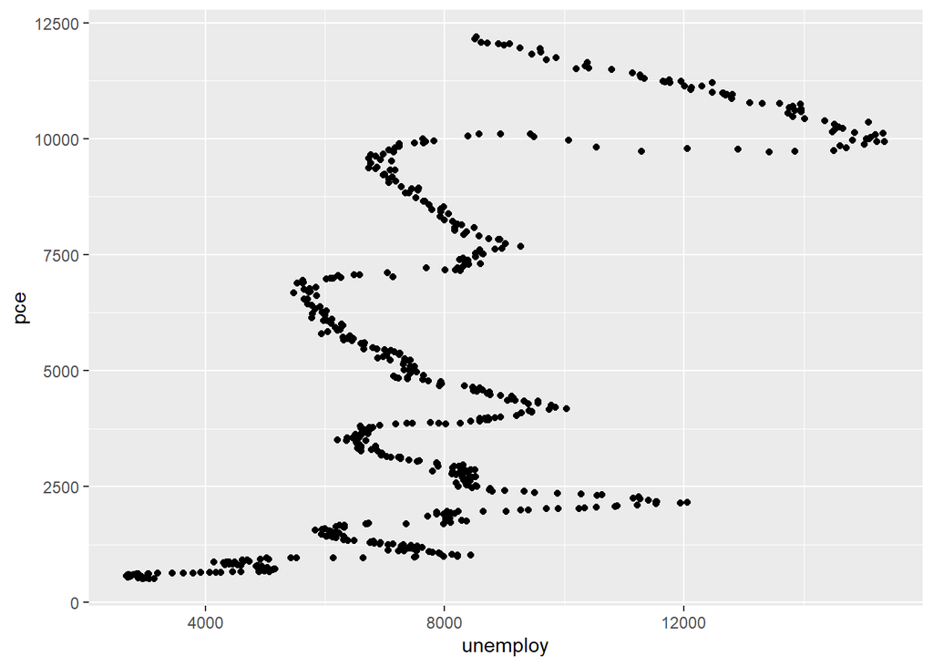

```r
#?economics

plot <- ggplot(data = economics, aes(x = unemploy, y = pce)) +
  geom_point()

plot
```

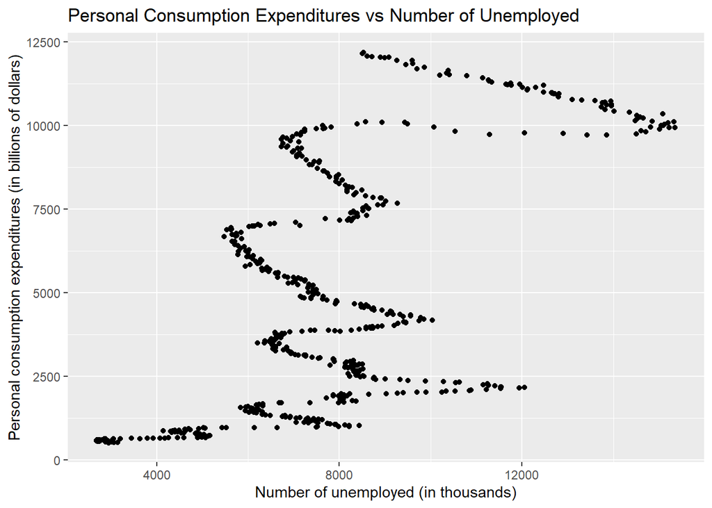

```r
plot_labeled <- plot +
  labs(
    title = "Personal Consumption Expenditures vs Number of Unemployed",
    x = "Number of unemployed (in thousands)",
    y = "Personal consumption expenditures (in billions of dollars)"
  )

plot_labeled
```

# 8 #Ex 8. Replicate the chart using a pipe and without saving the initial plot

**Ans:**

[figure not shown]

Figure 1: Scatter plot of consumption expenditures (PCE) vs unemployment.

```r
library(ggplot2)

economics |>
  ggplot(aes(x = unemploy, y = pce)) +
  geom_point() +
  labs(
    title = "Personal Consumption Expenditures vs Number of Unemployed",
    x = "Number of unemployed (in thousands)",
    y = "Personal consumption expenditures (in billions of dollars)"
  )
```

# 9 #Ex 9. Use a callout block to describe findings and cross-reference the figure

**Note**

There may be clusters reflecting different economic periods (e.g., recessions vs expansions).

A next step could be adding a smoother (like `geom_smooth()`) to better visualize the trend.

# 10 #Ex 10. Make the codebook organized and beautiful, and explicitly state what you did……

**Ans:**